# CreditCardChurners

By Saba Akram

6/10/2021

The customers of the Bank are leaving the credit card services in large numbers. Therefore, in our research project we are going to apply the Data Visualization and Business Intelligence techniques in order to find the respectable solution. Here we have imported the data below. Lets have a little look.

```r
BankChurners <- read.csv("D:/Research Materials/Credit Card Churners/BankChurners.csv", stringsAsFactors=TRUE)
library(ggplot2)
```

We see that there are 23 columns and 10127 records of the customers. Let’s take a look at the variables :-

- CLIENTNUM - This is client identity number. Each customer has a unique identity number.
- Attrition_Flag - This variable shows the status of the customer whether the customer is existing or have attrited(Churned).
- Customer_Age- Demographic Variable. Customer’s age in years.
- Gender- Demographic Variable M=Male and F=Female.
- Dependent_count - Demographic Variables. Number of Dependents.
- Education_Level- Demographic Variable.“Unknown, Uneducated, High School, Graduted, Post-Graduate, Doctorate and College”.
- Marital_Status - Demographic Variable. “Unknown, Married, Single and Divorced”.
- Income_Category - Demographic Variable. Annual Income category of the account holder. “Unknown, Less than $40k, $40k-$60k, $60k-$80k, $80k-$120k and $120+”.
- Card_Category - Product variable. Type of Card - Blue, Silver, GOld and Platinum.
- Month_on_the_book - Period of relationship with the bank.
- Total_Relationship_count - Total number of products held by customer.
- Months_Inactive_12_mon - Numbers of months inactive in last 12 months.
- Contacts_count_12_mon - Number of contacts in the last 12 months.
- Credit_Limit - Credit limit on the credit card.
- Total_Revolving_Balance - Total revolving balance on the credit card.
- Avg_open_to_buy - Open to buy credit line (Average of last 12 months.)
- Total_Amt_chng_Q4_Q1 - Change in Transaction Amount (Q4 over Q1).
- Total_Trans_Amt - Total Transaction Amount (Last 12 months).
- Total_Trans_Ct - Total transaction count (Last 12 months).
- Total_Ct_Chng_Q4_Q1 - Change in Transaction Count (Q4 over Q1).
- Avg_Utilization_Ratio - Average Card Utilization Ratio.

There are two more variables which is not required. Therefore Let’s omit these last two columns.

```r
BankChurners<-BankChurners[,-c(22:23)]
colnames(BankChurners)
```

```
##  [1] "CLIENTNUM"                "Attrition_Flag"
##  [3] "Customer_Age"             "Gender"
##  [5] "Dependent_count"          "Education_Level"
##  [7] "Marital_Status"           "Income_Category"
##  [9] "Card_Category"            "Months_on_book"
## [11] "Total_Relationship_Count" "Months_Inactive_12_mon"
## [13] "Contacts_Count_12_mon"    "Credit_Limit"
## [15] "Total_Revolving_Bal"      "Avg_Open_To_Buy"
## [17] "Total_Amt_Chng_Q4_Q1"     "Total_Trans_Amt"
## [19] "Total_Trans_Ct"           "Total_Ct_Chng_Q4_Q1"
## [21] "Avg_Utilization_Ratio"
```

Now the data set contains 20 predictors worth of information of 10127 customers along with the target variable, “Attrition_Flag”, an indication of whether the customer churned or not. We will try to visualize univariate relationships and then try to visualize multivariate relationships among the predictors and the target variable.

## **Getting to know about the Attrition_Flag**

```r
# Counting the number of existing customers and attrited customers.
attrition_count<-table(BankChurners$Attrition_Flag)
attrition_count
```

```
##
## Attrited Customer Existing Customer
##              1627              8500
```

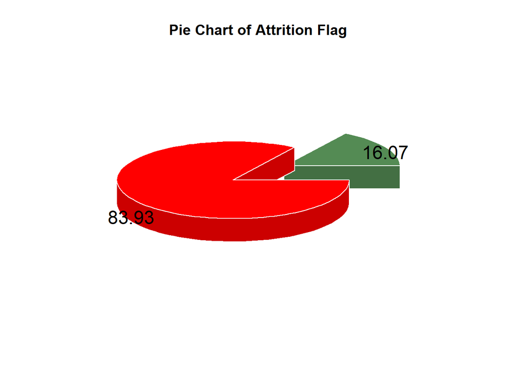

```r
# Calculating the percentage of the existing customers and the attrited customers.
attrition_percent<-round(prop.table(attrition_count)*100,2)

# Showing it through the pie chart

library(plotrix)
pie3D(attrition_percent,col = c("palegreen4","red"),labels = attrition_percent, explode = 0.25,labelcol = "black", border = "white",main="Pie Chart of Attrition Flag")
```

After observing from the above findings, we get that 1627 customer out of 10127 customers which equals 16.07% of the customers attrited(churned) the credit card service provided by the bank.

One of the primary reasons for applying “Data Visualization and Business Intelligence” is to investigate the variables, examine the distributions of the categorical variables, look at the histograms of the numeric variables, and explore the relationships among sets of variables. In this way, we can visualize the data while keeping an eye on our overall goal. We begin by considering the categorical variables, and their relationship to the attrition.

## **Exploring Categorical variables**

Here we have Income_Category, Card_category, Education_Level, Marital_Status and Gender as the categorical variables and we will look at them one by one by visualizing them.

### Attrition_Flag - Income_Category

```r
counts<-table(BankChurners$Attrition_Flag,BankChurners$Income_Category,dnn = c("Attrition_Flag","Income_Category"))
counts
```

```
##                    Income_Category
## Attrition_Flag      $120K + $40K - $60K $60K - $80K $80K - $120K Less than $40K
##   Attrited Customer     126         271         189          242            612
##   Existing Customer     601        1519        1213         1293           2949
##                    Income_Category
## Attrition_Flag      Unknown
##   Attrited Customer     187
##   Existing Customer     925
```

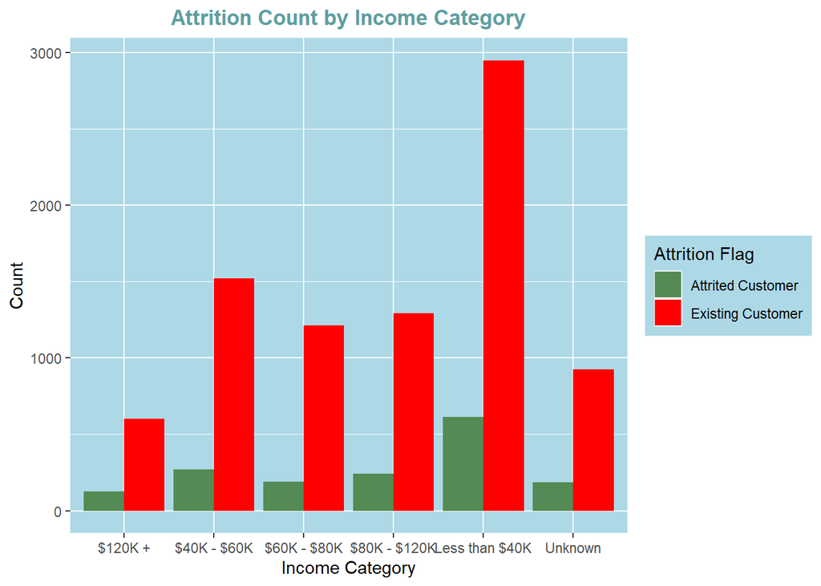

```r
ggplot(data = BankChurners,aes(x=Income_Category,fill=Attrition_Flag))+geom_bar(position = "dodge")+labs(title = "Attrition Count by Income Category",x="Income Category",fill="Attrition Flag")+theme(panel.background = element_rect(fill = "lightblue"))+theme(plot.title = element_text(hjust = 0.5,face = "bold",colour = "cadetblue"))+scale_x_discrete("Income Category")+scale_y_continuous("Count")+scale_fill_manual(values=c("palegreen4","red"))+theme(legend.background = element_rect(fill = "lightblue"))
```

```r
# Income_Category wise proportion
row.margin<-round(prop.table(counts,margin = 1),4)*100
row.margin
```

```
##                    Income_Category
## Attrition_Flag      $120K + $40K - $60K $60K - $80K $80K - $120K Less than $40K
##   Attrited Customer    7.74       16.66       11.62        14.87          37.62
##   Existing Customer    7.07       17.87       14.27        15.21          34.69
##                    Income_Category
## Attrition_Flag      Unknown
##   Attrited Customer   11.49
##   Existing Customer   10.88
```

```r
#Attrition_Flag wise proportion
col.margin<-round(prop.table(counts,margin = 2),4)*100
col.margin
```

```
##                    Income_Category
## Attrition_Flag      $120K + $40K - $60K $60K - $80K $80K - $120K Less than $40K
##   Attrited Customer   17.33       15.14       13.48        15.77          17.19
##   Existing Customer   82.67       84.86       86.52        84.23          82.81
##                    Income_Category
## Attrition_Flag      Unknown
##   Attrited Customer   16.82
##   Existing Customer   83.18
```

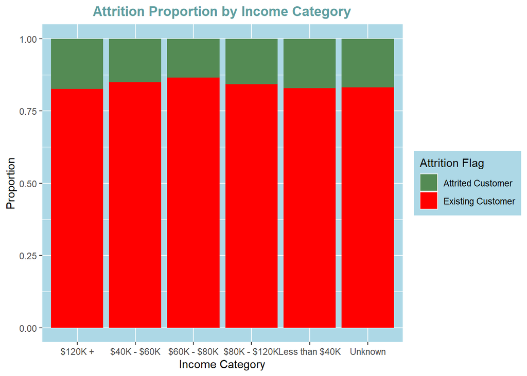

```r
ggplot(data = BankChurners,aes(x=Income_Category,fill=Attrition_Flag))+geom_bar(position = "fill")+scale_x_discrete("Income Category")+scale_y_continuous("Proportion")+labs(title = "Attrition Proportion by Income Category",x="Income Category",fill="Attrition Flag")+theme(panel.background = element_rect(fill = "lightblue"))+theme(plot.title = element_text(hjust = 0.5,face = "bold",colour = "cadetblue"))+scale_fill_manual(values=c("palegreen4","red"))+theme(legend.background = element_rect(fill = "lightblue"))
```

### Attrition_Flag - Card_Category

```r
counts<-table(BankChurners$Attrition_Flag,BankChurners$Card_Category,dnn = c("Attrition_Flag","Card_Category"))
counts
```

```
##                    Card_Category
## Attrition_Flag      Blue Gold Platinum Silver
##   Attrited Customer 1519   21        5     82
##   Existing Customer 7917   95       15    473
```

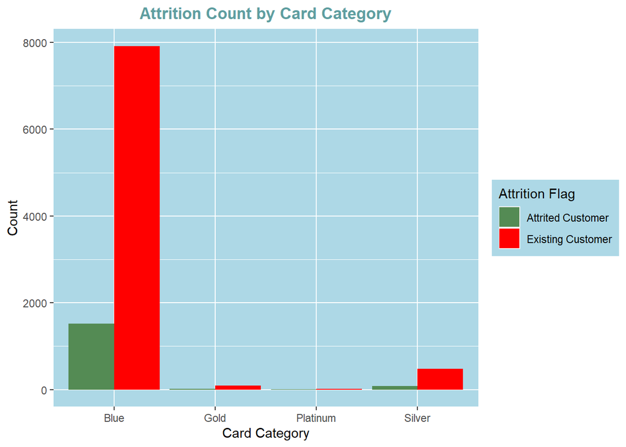

```r
ggplot(data = BankChurners,aes(x=Card_Category,fill=Attrition_Flag))+geom_bar(position = "dodge")+labs(title = "Attrition Count by Card Category",x="Card Category",fill="Attrition Flag")+theme(panel.background = element_rect(fill = "lightblue"))+theme(plot.title = element_text(hjust = 0.5,face = "bold",colour = "cadetblue"))+scale_x_discrete("Card Category")+scale_y_continuous("Count")+scale_fill_manual(values=c("palegreen4","red"))+theme(legend.background = element_rect(fill = "lightblue"))
```

```r
# Card_Category wise proportion
row.margin<-round(prop.table(counts,margin = 1),4)*100
row.margin
```

```
##                    Card_Category
## Attrition_Flag       Blue  Gold Platinum Silver
##   Attrited Customer 93.36  1.29     0.31   5.04
##   Existing Customer 93.14  1.12     0.18   5.56
```

```r
#Attrition_Flag wise proportion
col.margin<-round(prop.table(counts,margin = 2),4)*100
col.margin
```

```
##                    Card_Category
## Attrition_Flag       Blue  Gold Platinum Silver
##   Attrited Customer 16.10 18.10    25.00  14.77
##   Existing Customer 83.90 81.90    75.00  85.23
```

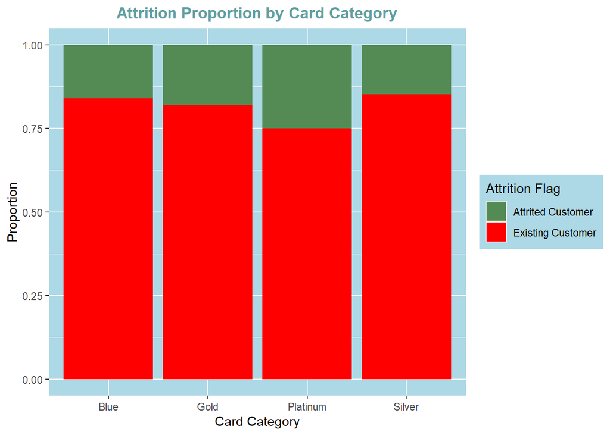

```r
ggplot(data = BankChurners,aes(x=Card_Category,fill=Attrition_Flag))+geom_bar(position = "fill")+scale_x_discrete("Card Category")+scale_y_continuous("Proportion")+labs(title = "Attrition Proportion by Card Category",x="Card Category",fill="Attrition Flag")+theme(panel.background = element_rect(fill = "lightblue"))+theme(plot.title = element_text(hjust = 0.5,face = "bold",colour = "cadetblue"))+scale_fill_manual(values=c("palegreen4","red"))+theme(legend.background = element_rect(fill = "lightblue"))
```

1. From the above graphs and tables we observe that the customers use blue card the most more than 93% followed by the silver card.
2. With the minimum usage of the platinum and gold cards, the bank has maximum attrition rate in platinum (25%) followed by the gold card (18.1%). The bank should take this conclusion very seriously. The Bank may provide various incentives to customers to motivate them towards using the Platinum and Gold Cards.
3. The Silver card customers consists of only 5%. The use of Silver Card should also be promoted.

### Attrition_Flag - Education_Level

```r
counts<-table(BankChurners$Attrition_Flag,BankChurners$Education_Level,dnn = c("Attrition_Flag","Education_Level"))
counts
```

```
##                    Education_Level
## Attrition_Flag      College Doctorate Graduate High School Post-Graduate
##   Attrited Customer     154        95      487         306            92
##   Existing Customer     859       356     2641        1707           424
##                    Education_Level
## Attrition_Flag      Uneducated Unknown
##   Attrited Customer        237     256
##   Existing Customer       1250    1263
```

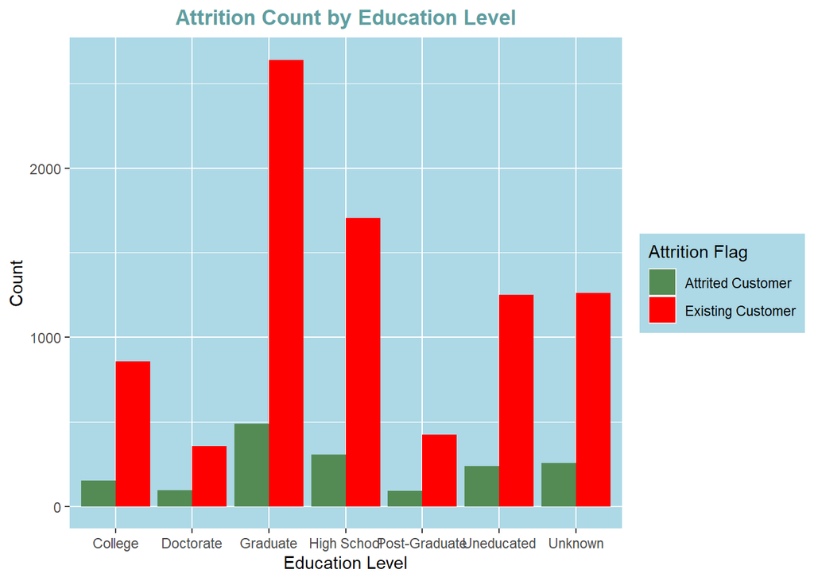

```r
ggplot(data = BankChurners,aes(x=Education_Level,fill=Attrition_Flag))+geom_bar(position = "dodge")+labs(title = "Attrition Count by Education Level",x="Education Level",fill="Attrition Flag")+theme(panel.background = element_rect(fill = "lightblue"))+theme(plot.title = element_text(hjust = 0.5,face = "bold",colour = "cadetblue"))+scale_x_discrete("Education Level")+scale_y_continuous("Count")+scale_fill_manual(values=c("palegreen4","red"))+theme(legend.background = element_rect(fill = "lightblue"))
```

```r
# Education_Level wise proportion
row.margin<-round(prop.table(counts,margin = 1),4)*100
row.margin
```

```
##                    Education_Level
## Attrition_Flag      College Doctorate Graduate High School Post-Graduate
##   Attrited Customer    9.47      5.84    29.93       18.81          5.65
##   Existing Customer   10.11      4.19    31.07       20.08          4.99
##                    Education_Level
## Attrition_Flag      Uneducated Unknown
##   Attrited Customer      14.57   15.73
##   Existing Customer      14.71   14.86
```

```r
#Attrition_Flag wise proportion
col.margin<-round(prop.table(counts,margin = 2),4)*100
col.margin
```

```
##                    Education_Level
## Attrition_Flag      College Doctorate Graduate High School Post-Graduate
##   Attrited Customer   15.20     21.06    15.57       15.20         17.83
##   Existing Customer   84.80     78.94    84.43       84.80         82.17
##                    Education_Level
## Attrition_Flag      Uneducated Unknown
##   Attrited Customer      15.94   16.85
##   Existing Customer      84.06   83.15
```

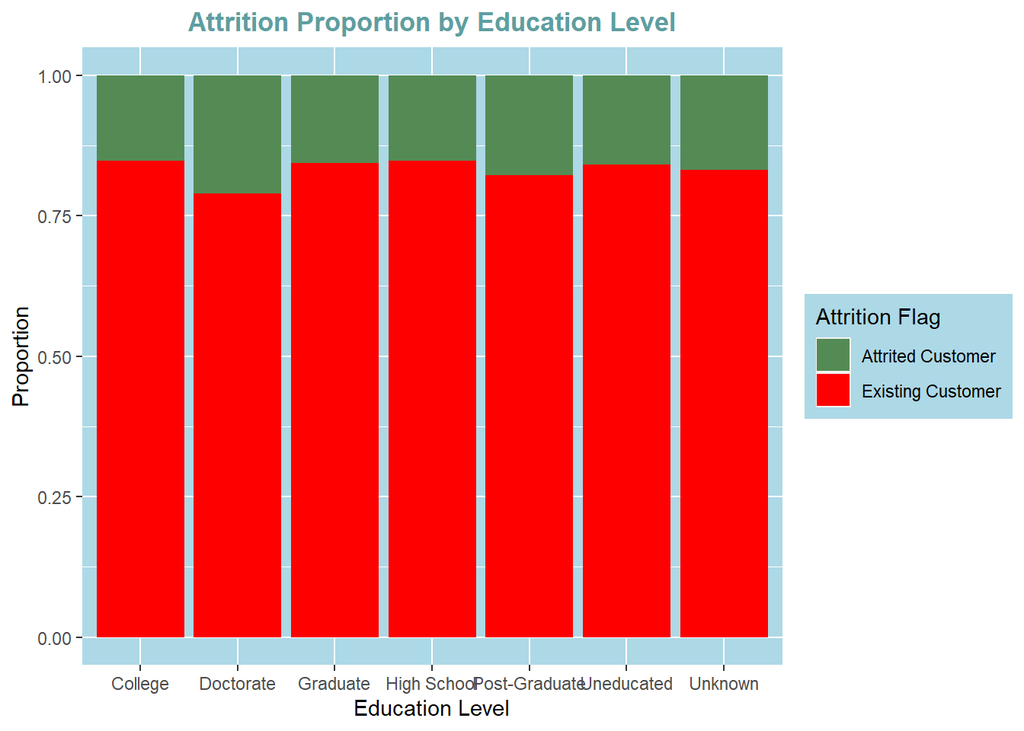

```r
ggplot(data = BankChurners,aes(x=Education_Level,fill=Attrition_Flag))+geom_bar(position = "fill")+scale_x_discrete("Education Level")+scale_y_continuous("Proportion")+labs(title = "Attrition Proportion by Education Level",x="Education Level",fill="Attrition Flag")+theme(panel.background = element_rect(fill = "lightblue"))+theme(plot.title = element_text(hjust = 0.5,face = "bold",colour = "cadetblue"))+scale_fill_manual(values=c("palegreen4","red"))+theme(legend.background = element_rect(fill = "lightblue"))
```

1. From the above graphs and the tables we observe that the society attached with the bank are civilized and educated but at the same time uneducated customers consists of approx 14%.
2. We observe that the customers belong to the Post-Graduate and Doctorate category seems to churn the credit card facility at a higher rate than the others with 17.83% and 21.06% attrition rates respectively. Since the top most educated category has the problem with the service, the bank should try to readjst its credit card facilities wisely.

### Attrition_Flag - Marital_Status

```r
counts<-table(BankChurners$Attrition_Flag,BankChurners$Marital_Status,dnn = c("Attrition_Flag","Marital_Status"))
counts
```

```
##                    Marital_Status
## Attrition_Flag      Divorced Married Single Unknown
##   Attrited Customer      121     709    668     129
##   Existing Customer      627    3978   3275     620
```

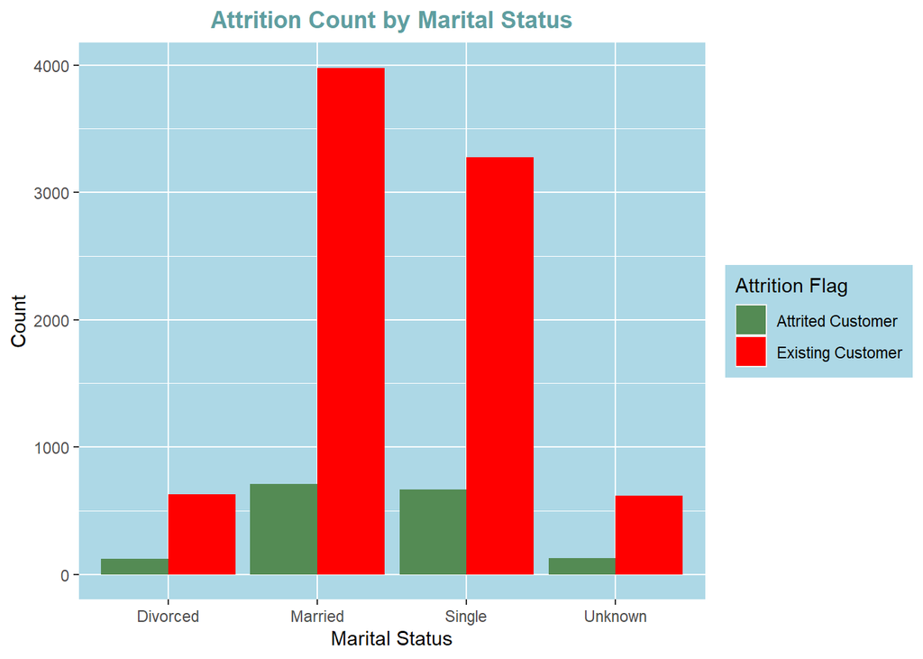

```r
ggplot(data = BankChurners,aes(x=Marital_Status,fill=Attrition_Flag))+geom_bar(position = "dodge")+labs(title = "Attrition Count by Marital Status",x="Marital Status",fill="Attrition Flag")+theme(panel.background = element_rect(fill = "lightblue"))+theme(plot.title = element_text(hjust = 0.5,face = "bold",colour = "cadetblue"))+scale_x_discrete("Marital Status")+scale_y_continuous("Count")+scale_fill_manual(values=c("palegreen4","red"))+theme(legend.background = element_rect(fill = "lightblue"))
```

```r
# Marital_Status wise proportion
row.margin<-round(prop.table(counts,margin = 1),4)*100
row.margin
```

```
##                    Marital_Status
## Attrition_Flag      Divorced Married Single Unknown
##   Attrited Customer     7.44   43.58  41.06    7.93
##   Existing Customer     7.38   46.80  38.53    7.29
```

```r
#Attrition_Flag wise proportion
col.margin<-round(prop.table(counts,margin = 2),4)*100
col.margin
```

```
##                    Marital_Status
## Attrition_Flag      Divorced Married Single Unknown
##   Attrited Customer    16.18   15.13  16.94   17.22
##   Existing Customer    83.82   84.87  83.06   82.78
```

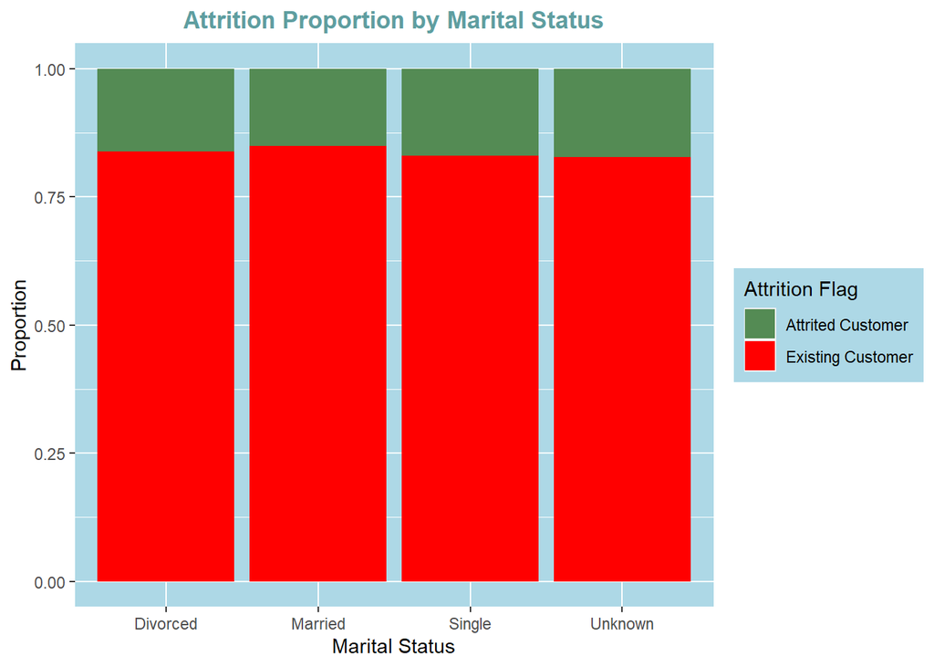

```r
ggplot(data = BankChurners,aes(x=Marital_Status,fill=Attrition_Flag))+geom_bar(position = "fill")+scale_x_discrete("Marital Status")+scale_y_continuous("Proportion")+labs(title = "Attrition Proportion by Marital Status",x="Marital Status",fill="Attrition Flag")+theme(panel.background = element_rect(fill = "lightblue"))+theme(plot.title = element_text(hjust = 0.5,face = "bold",colour = "cadetblue"))+scale_fill_manual(values=c("palegreen4","red"))+theme(legend.background = element_rect(fill = "lightblue"))
```

### Attrition_Flag - Gender

```r
counts<-table(BankChurners$Attrition_Flag,BankChurners$Gender,dnn = c("Attrition_Flag","Gender"))
counts
```

```
##                    Gender
## Attrition_Flag         F    M
##   Attrited Customer  930  697
##   Existing Customer 4428 4072
```

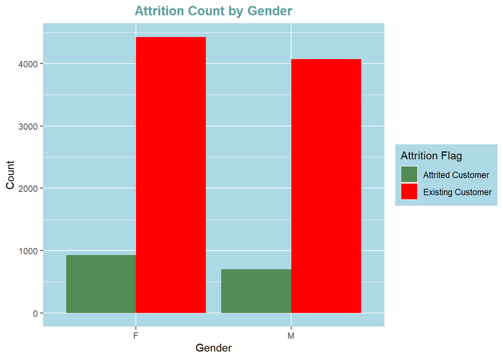

```r
ggplot(data = BankChurners,aes(x=Gender,fill=Attrition_Flag))+geom_bar(position = "dodge")+labs(title = "Attrition Count by Gender",x="Gender",fill="Attrition Flag")+theme(panel.background = element_rect(fill = "lightblue"))+theme(plot.title = element_text(hjust = 0.5,face = "bold",colour = "cadetblue"))+scale_x_discrete("Gender")+scale_y_continuous("Count")+scale_fill_manual(values=c("palegreen4","red"))+theme(legend.background = element_rect(fill = "lightblue"))
```

```r
# Gender wise proportion
row.margin<-round(prop.table(counts,margin = 1),4)*100
row.margin
```

```
##                    Gender
## Attrition_Flag          F     M
##   Attrited Customer 57.16 42.84
##   Existing Customer 52.09 47.91
```

```r
#Attrition_Flag wise proportion
col.margin<-round(prop.table(counts,margin = 2),4)*100
col.margin
```

```
##                    Gender
## Attrition_Flag          F     M
##   Attrited Customer 17.36 14.62
##   Existing Customer 82.64 85.38
```

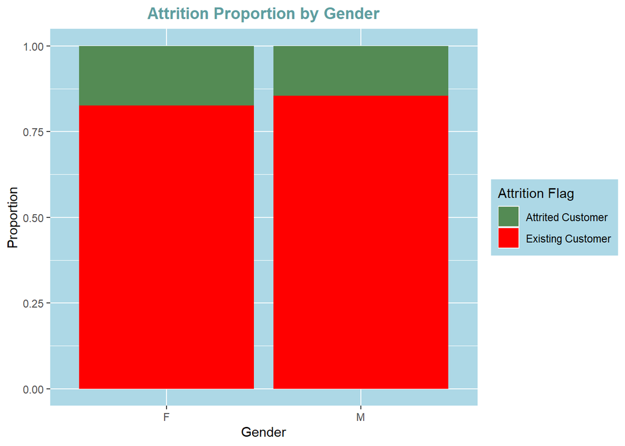

```r
ggplot(data = BankChurners,aes(x=Gender,fill=Attrition_Flag))+geom_bar(position = "fill")+scale_x_discrete("Gender")+scale_y_continuous("Proportion")+labs(title = "Attrition Proportion by Gender",x="Gender",fill="Attrition Flag")+theme(panel.background = element_rect(fill = "lightblue"))+theme(plot.title = element_text(hjust = 0.5,face = "bold",colour = "cadetblue"))+scale_fill_manual(values=c("palegreen4","red"))+theme(legend.background = element_rect(fill = "lightblue"))
```

1. More than 50% of the customers of the bank are females.
2. Females also have more attrition rate, as is clear from the graph and the table with 17.36%.

## **Exploring Numerical variables**

Now we have Customer_Age, Dependent_Count, Months_on_book, Total_relationship_count, months_inactive_12_mon, contacts_count_12_mon, credit_limit, Total_revolving_balance, Avg_open_to_buy, Total_amt_chng_Q4_Q1, Total_Trans_Amt, Total_Trans_count, Total_count_chng_Q4_Q1 and Avg_utilization_Ratio as the numerical variables and we will look at them one by one by visualizing them.

### Attrition_Flag - Customer_Age

```r
summary(BankChurners$Customer_Age)
```

```
##    Min. 1st Qu.  Median    Mean 3rd Qu.    Max.
##   26.00   41.00   46.00   46.33   52.00   73.00
```

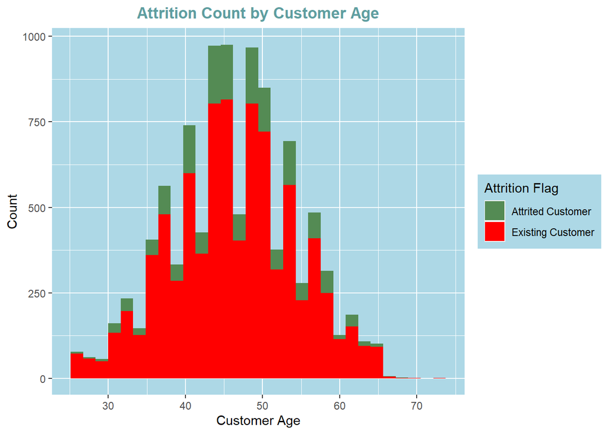

```r
ggplot(data = BankChurners,aes(x=Customer_Age,fill=Attrition_Flag))+geom_histogram(position = "stack",bins = 30)+scale_x_continuous("Customer Age")+scale_y_continuous("Count")+labs(title = "Attrition Count by Customer Age",x="Customer Age",fill="Attrition Flag")+theme(panel.background = element_rect(fill = "lightblue"))+theme(plot.title = element_text(hjust = 0.5,face = "bold",colour = "cadetblue"))+scale_fill_manual(values=c("palegreen4","red"))+theme(legend.background = element_rect(fill = "lightblue"))
```

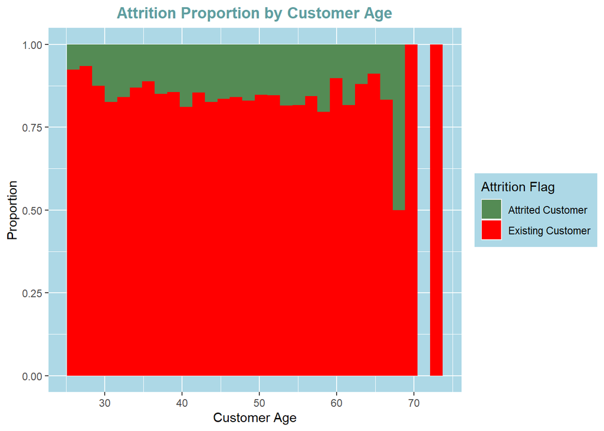

```r
ggplot(data = BankChurners,aes(x=Customer_Age,fill=Attrition_Flag))+geom_histogram(position = "fill",bins = 30)+scale_x_continuous("Customer Age")+scale_y_continuous("Proportion")+labs(title = "Attrition Proportion by Customer Age",x="Customer Age",fill="Attrition Flag")+theme(panel.background = element_rect(fill = "lightblue"))+theme(plot.title = element_text(hjust = 0.5,face = "bold",colour = "cadetblue"))+scale_fill_manual(values=c("palegreen4","red"))+theme(legend.background = element_rect(fill = "lightblue"))
```

### Attrition_Flag - Dependent_Count

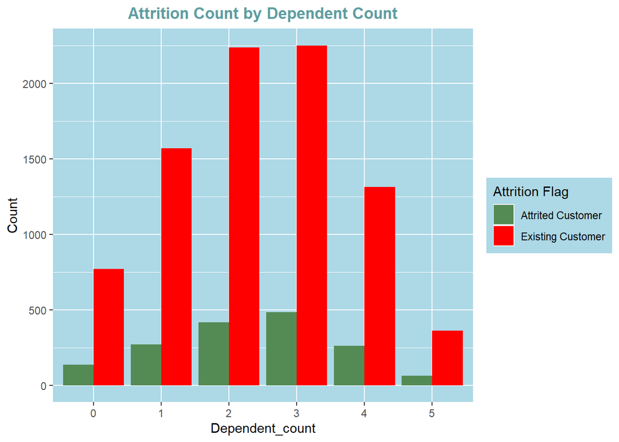

```r
ggplot()+geom_bar(data = BankChurners,aes(x=factor(Dependent_count),fill=factor(Attrition_Flag)),position="dodge")+scale_x_discrete("Dependent_count")+scale_y_continuous("Count")+guides(fill=guide_legend(title = "Attrition Flag"))+scale_fill_manual(values = c("palegreen4","red"))+labs(title = "Attrition Count by Dependent Count",x="Dependent Count",fill="Attrition Flag")+theme(panel.background = element_rect(fill = "lightblue"))+theme(plot.title = element_text(hjust = 0.5,face = "bold",colour = "cadetblue"))+theme(legend.background = element_rect(fill = "lightblue"))
```

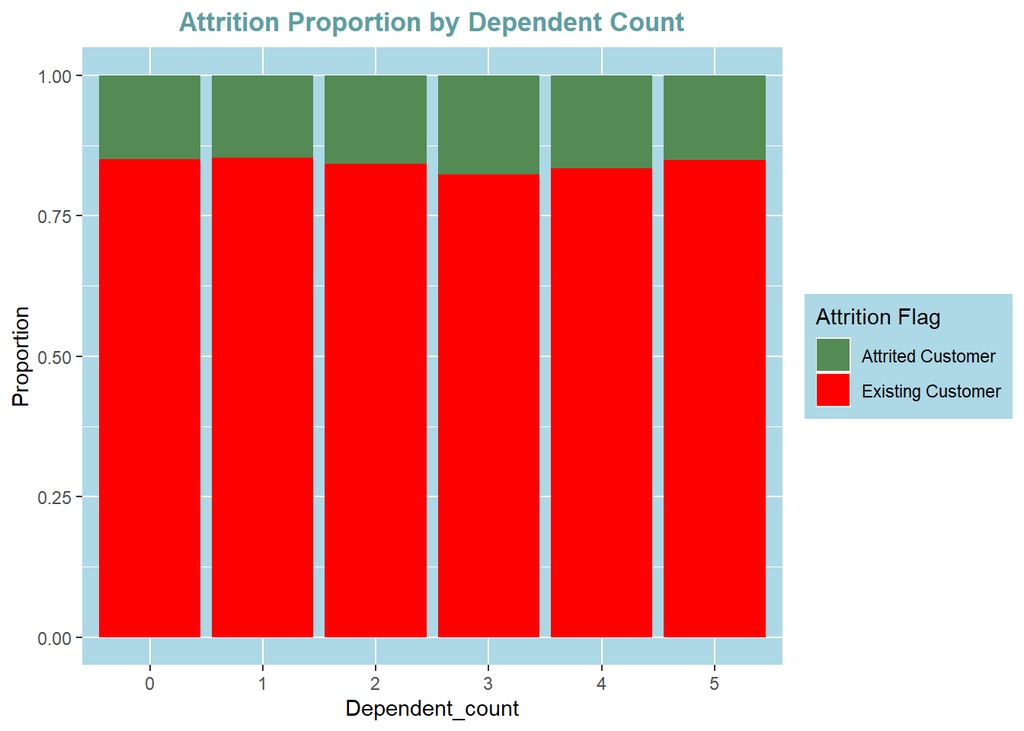

```r
ggplot()+geom_bar(data = BankChurners,aes(x=factor(Dependent_count),fill=factor(Attrition_Flag)),position="fill")+scale_x_discrete("Dependent_count")+scale_y_continuous("Proportion")+guides(fill=guide_legend(title = "Attrition Flag"))+scale_fill_manual(values = c("palegreen4","red"))+labs(title = "Attrition Proportion by Dependent Count",x="Dependent Count",fill="Attrition Flag")+theme(panel.background = element_rect(fill = "lightblue"))+theme(plot.title = element_text(hjust = 0.5,face = "bold",colour = "cadetblue"))+theme(legend.background = element_rect(fill = "lightblue"))
```

### Attrition_Flag - Months_on_book(Period of relationship with the bank.)

```r
summary(BankChurners$Months_on_book)
```

```
##    Min. 1st Qu.  Median    Mean 3rd Qu.    Max.
##   13.00   31.00   36.00   35.93   40.00   56.00
```

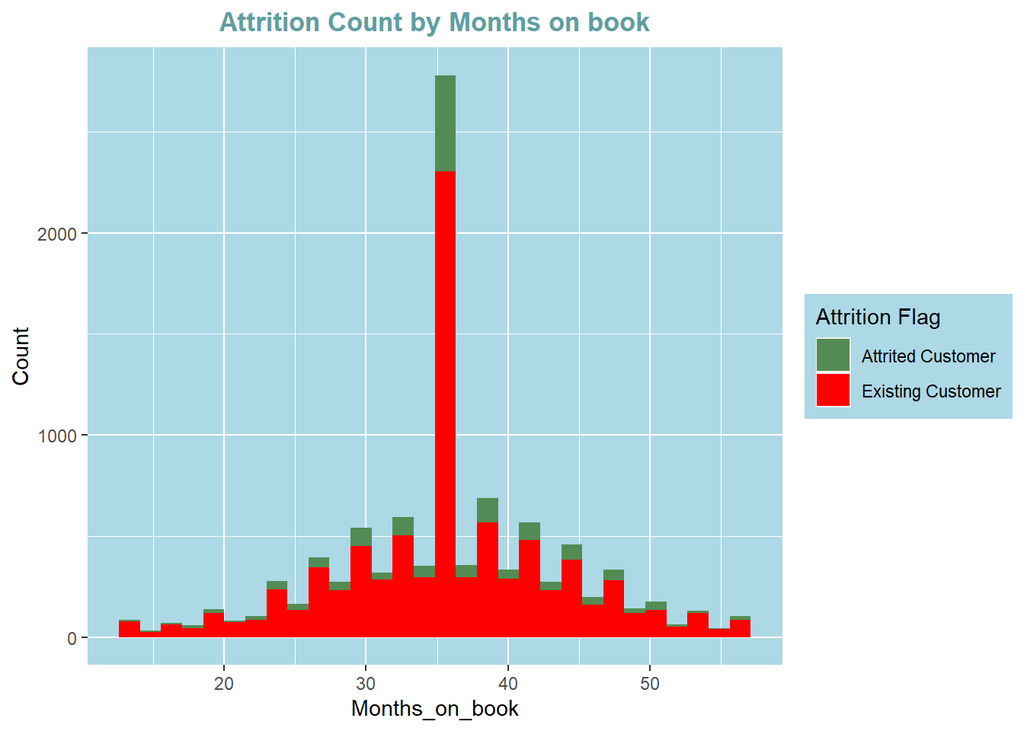

```r
ggplot(data = BankChurners,aes(x=Months_on_book,fill=Attrition_Flag))+geom_histogram(position = "stack",bins = 30)+scale_x_continuous("Months_on_book")+scale_y_continuous("Count")+guides(fill=guide_legend(title = "Attrition Flag"))+scale_fill_manual(values = c("palegreen4","red"))+labs(title = "Attrition Count by Months on book",x="Months on book",fill="Attrition Flag")+theme(panel.background = element_rect(fill = "lightblue"))+theme(plot.title = element_text(hjust = 0.5,face = "bold",colour = "cadetblue"))+theme(legend.background = element_rect(fill = "lightblue"))
```

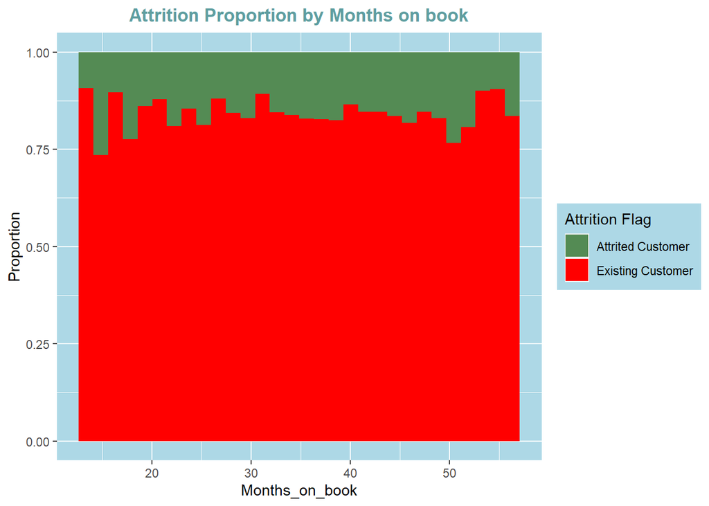

```r
ggplot(data = BankChurners,aes(x=Months_on_book,fill=Attrition_Flag))+geom_histogram(position = "fill",bins = 30)+scale_x_continuous("Months_on_book")+scale_y_continuous("Proportion")+guides(fill=guide_legend(title = "Attrition Flag"))+scale_fill_manual(values = c("palegreen4","red"))+labs(title = "Attrition Proportion by Months on book",x="Months on book",fill="Attrition Flag")+theme(panel.background = element_rect(fill = "lightblue"))+theme(plot.title = element_text(hjust = 0.5,face = "bold",colour = "cadetblue"))+theme(legend.background = element_rect(fill = "lightblue"))
```

1. From the above graph, we observe that most of customers of the bank consists of the customers with 30-40 Periods of relationship with the bank.
2. However overall we see that the attrition rate is constant throughout but if we observe closely, from the second proportionate graph we get that the customers with very small and very large period of the relationship with the bank seems to churn at a higher attrition rate.

### Attrition_Flag -Months_Inactive_12_mon (Numbers of months inactive in last 12 months.)

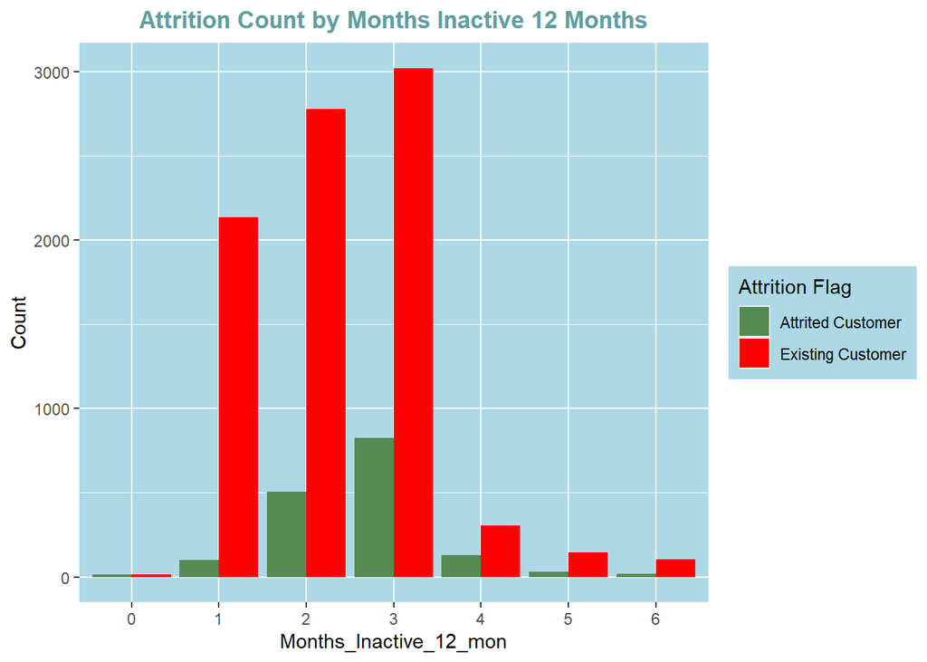

```r
ggplot()+geom_bar(data = BankChurners,aes(x=factor(Months_Inactive_12_mon),fill=factor(Attrition_Flag)),position="dodge")+scale_x_discrete("Months_Inactive_12_mon")+scale_y_continuous("Count")+guides(fill=guide_legend(title = "Attrition Flag"))+scale_fill_manual(values = c("palegreen4","red"))+labs(title = "Attrition Count by Months Inactive 12 Months",x="Months Inactive 12 months",fill="Attrition Flag")+theme(panel.background = element_rect(fill = "lightblue"))+theme(plot.title = element_text(hjust = 0.5,face = "bold",colour = "cadetblue"))+theme(legend.background = element_rect(fill = "lightblue"))
```

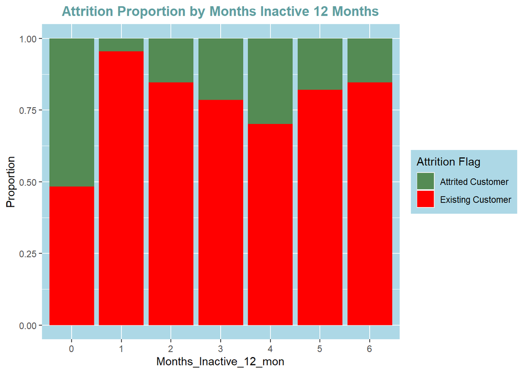

```r
ggplot()+geom_bar(data = BankChurners,aes(x=factor(Months_Inactive_12_mon),fill=factor(Attrition_Flag)),position="fill")+scale_x_discrete("Months_Inactive_12_mon")+scale_y_continuous("Proportion")+guides(fill=guide_legend(title = "Attrition Flag"))+scale_fill_manual(values = c("palegreen4","red"))+labs(title = "Attrition Proportion by Months Inactive 12 Months",x="Customer Age",fill="Attrition Flag")+theme(panel.background = element_rect(fill = "lightblue"))+theme(plot.title = element_text(hjust = 0.5,face = "bold",colour = "cadetblue"))+theme(legend.background = element_rect(fill = "lightblue"))
```

1. From the first above graph, we observe that there are very less customers who are inactive, while in the second graph we see that these active and regular customers have the maximum attrition rate which is extremely alarming. Therefore the bank should make the polcies keeping in mind for the regular customers.
2. Second thing we observe that the bank has almost all customers who remain inactive from 1 month minimum to 6 months minimum which is also not good for the healthy for the bank. We have maximum customers who are inactive for 3 months in last 12 months followed by 2 months followed by 1 month.
3. Also we see that from 1 inactive month to the 4 inactive months in the last 12 months, we have constantly increasing attrition rate.
4. The customers who were inactive 5 and 6 months in the last 12 months have the relatively low attrition rate.

### Attrition_Flag - Contacts_count_12_mon (Number of contacts in the last 12 months).

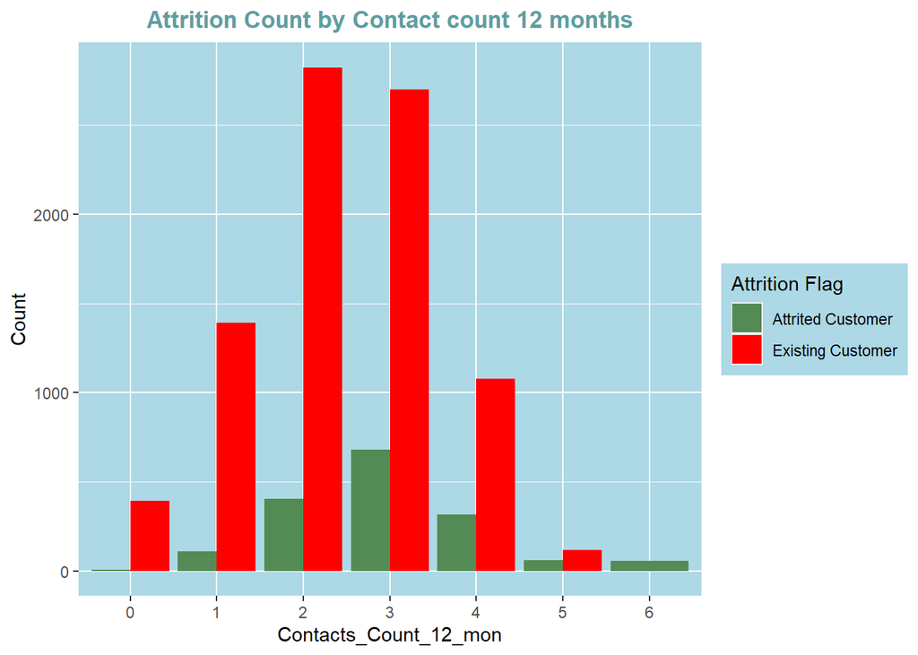

```r
ggplot()+geom_bar(data = BankChurners,aes(x=factor(Contacts_Count_12_mon),fill=factor(Attrition_Flag)),position="dodge")+scale_x_discrete("Contacts_Count_12_mon")+scale_y_continuous("Count")+guides(fill=guide_legend(title = "Attrition Flag"))+scale_fill_manual(values = c("palegreen4","red"))+labs(title = "Attrition Count by Contact count 12 months",x="Contact count 12 month",fill="Attrition Flag")+theme(panel.background = element_rect(fill = "lightblue"))+theme(plot.title = element_text(hjust = 0.5,face = "bold",colour = "cadetblue"))+theme(legend.background = element_rect(fill = "lightblue"))
```

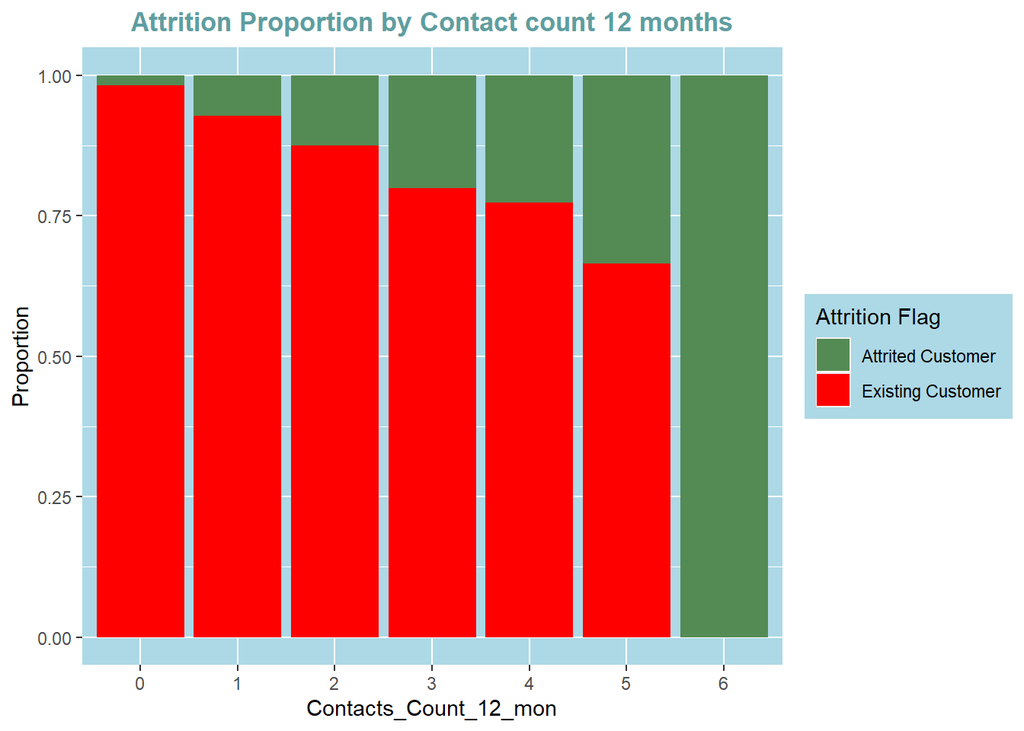

```r
ggplot()+geom_bar(data = BankChurners,aes(x=factor(Contacts_Count_12_mon),fill=factor(Attrition_Flag)),position="fill")+scale_x_discrete("Contacts_Count_12_mon")+scale_y_continuous("Proportion")+guides(fill=guide_legend(title = "Attrition Flag"))+scale_fill_manual(values = c("palegreen4","red"))+labs(title = "Attrition Proportion by Contact count 12 months",x="Contact count 12 months",fill="Attrition Flag")+theme(panel.background = element_rect(fill = "lightblue"))+theme(plot.title = element_text(hjust = 0.5,face = "bold",colour = "cadetblue"))+theme(legend.background = element_rect(fill = "lightblue"))
```

1. From the above first graph we observe that there are maximum customers in the banks with 2 and 3 contact counts, followed by 1 and 4 whic is indeed a very large proportion of the customers.
2. We also observe from the second graph that as the number of contact counts increases the attrition rate increases at a very fast rate indicating the the customers are not getting satisfied despite contacting.
3. The Bank should observe carefully the complaints of the customers who contacted and try to identfy the problem and reframe the credit card policies in order to remove the problems faced by the credit card customers

### Attrition_Flag - Credit_Limit (Credit limit on the credit card).

```r
summary(BankChurners$Credit_Limit)
```

```
##    Min. 1st Qu.  Median    Mean 3rd Qu.    Max.
##    1438    2555    4549    8632   11068   34516
```

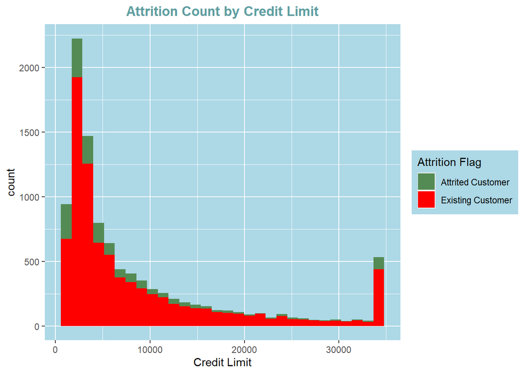

```r
ggplot(data = BankChurners,aes(x=Credit_Limit,fill=Attrition_Flag))+geom_histogram(position = "stack",bins = 30)+labs(title = "Attrition Count by Credit Limit",x="Credit Limit",fill="Attrition Flag")+theme(panel.background = element_rect(fill = "lightblue"))+theme(plot.title = element_text(hjust = 0.5,face = "bold",colour = "cadetblue"))+scale_fill_manual(values=c("palegreen4","red"))+theme(legend.background = element_rect(fill = "lightblue"))
```

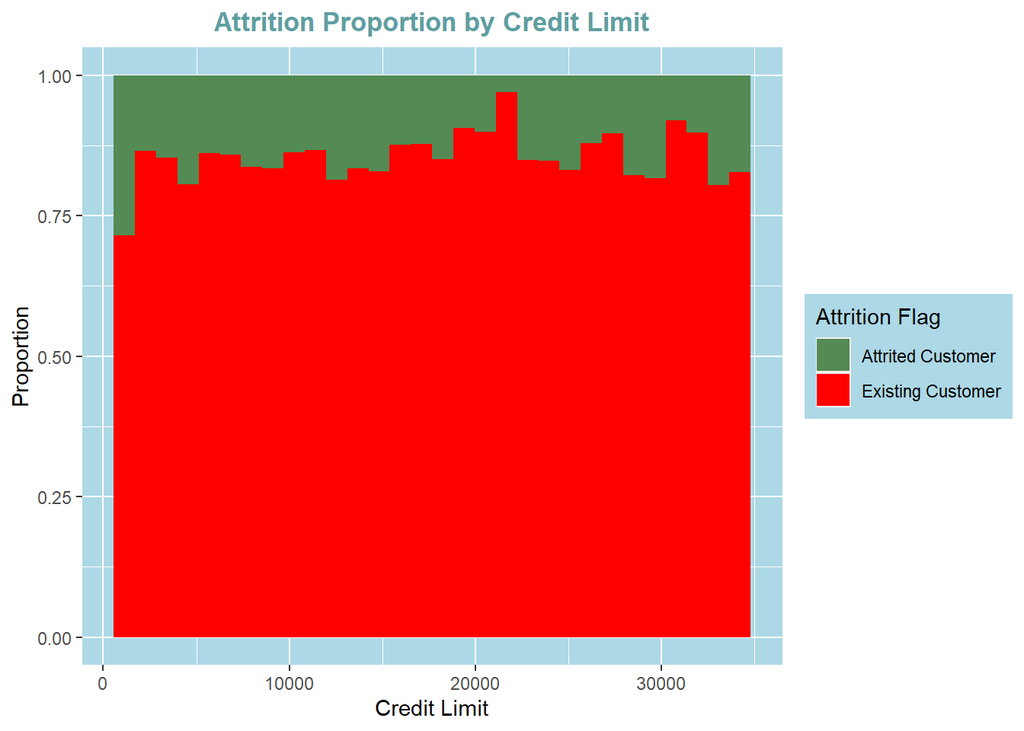

```r
ggplot(data = BankChurners,aes(x=Credit_Limit,fill=Attrition_Flag))+geom_histogram(position = "fill",bins = 30)+scale_x_continuous("Credit Limit")+scale_y_continuous("Proportion")+labs(title = "Attrition Proportion by Credit Limit",x="Credit Limit",fill="Attrition Flag")+theme(panel.background = element_rect(fill = "lightblue"))+theme(plot.title = element_text(hjust = 0.5,face = "bold",colour = "cadetblue"))+scale_fill_manual(values=c("palegreen4","red"))+theme(legend.background = element_rect(fill = "lightblue"))
```

### Attrition_Flag -Total_Revolving_Balance.

```r
summary(BankChurners$Total_Revolving_Bal)
```

```
##    Min. 1st Qu.  Median    Mean 3rd Qu.    Max.
##       0     359    1276    1163    1784    2517
```

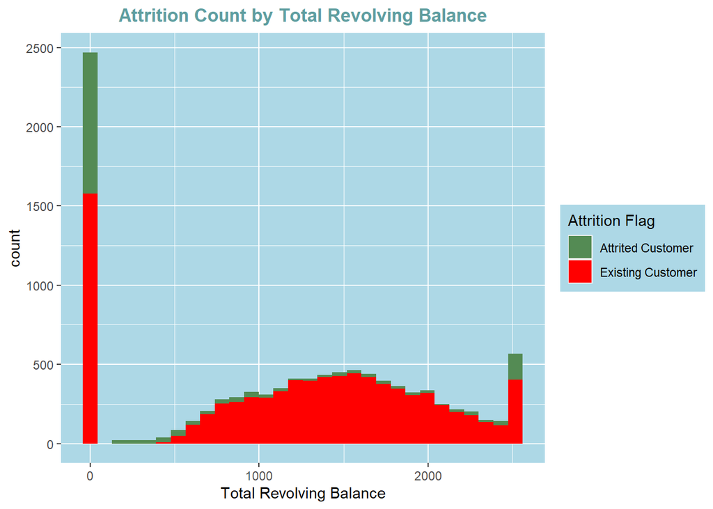

```r
ggplot(data = BankChurners,aes(x=Total_Revolving_Bal,fill=Attrition_Flag))+geom_histogram(position = "stack",bins = 30)+labs(title = "Attrition Count by Total Revolving Balance",x="Total Revolving Balance",fill="Attrition Flag")+theme(panel.background = element_rect(fill = "lightblue"))+theme(plot.title = element_text(hjust = 0.5,face = "bold",colour = "cadetblue"))+scale_fill_manual(values=c("palegreen4","red"))+theme(legend.background = element_rect(fill = "lightblue"))
```

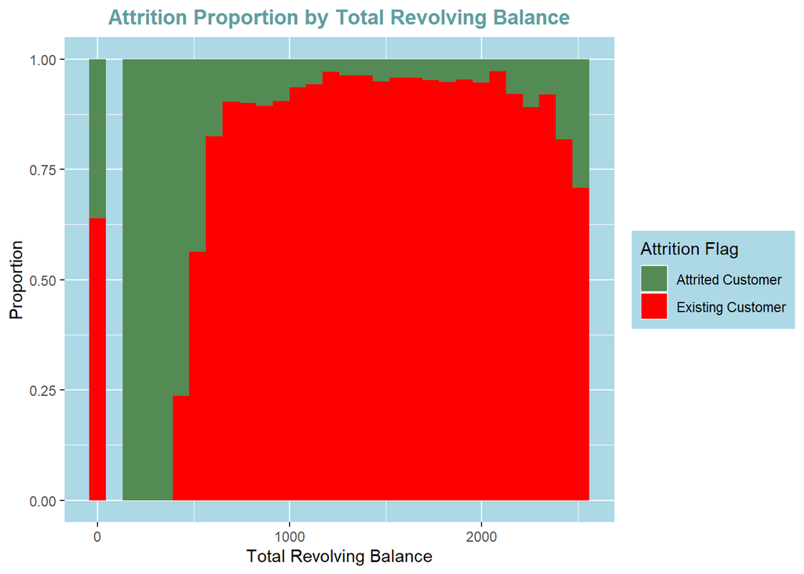

```r
ggplot(data = BankChurners,aes(x=Total_Revolving_Bal,fill=Attrition_Flag))+geom_histogram(position = "fill",bins = 30)+labs(title = "Attrition Proportion by Total Revolving Balance",x="Total Revolving Balance",fill="Attrition Flag")+theme(panel.background = element_rect(fill = "lightblue"))+theme(plot.title = element_text(hjust = 0.5,face = "bold",colour = "cadetblue"))+scale_fill_manual(values=c("palegreen4","red"))+theme(legend.background = element_rect(fill = "lightblue"))+scale_y_continuous("Proportion")
```

1. From the above graphs we can say that there are approximately 2500 customers who have not any Revolving Balance which is itself a very large nuumber. Also thuus section has a very large attrition rate (approximately 35%). Therefore we can conclude that the customers with the ) Total Revolving Balance should be the area of concern.
2. Next thing we observe that there are more customers with the Total Revolving Balance from 1000 to 2000. The Total Revolving Balance starts decreasing after 1600 and continues to decrease till 2500 until we get a huge increase in the customers with approx 2600 Total Revolving Balance.
3. From the proportionate graph above we get that, the Bank has maximum Attrition rate with the customers with the low Total Revolving Balance. As the Total Revolving Balance with the customers increases, the attrition rate starts decreases.
4. Also we see that beyond 2000 Total Revolving Balance the attrition rate again starts increasing. Therefore the bank’s focus should be on the customers with the low and high Total Revolving Balance.

### Attrition_Flag - Avg_open_to_buy (Open to buy credit line (Average of last 12 months.))

```r
summary(BankChurners$Avg_Open_To_Buy)
```

```
##    Min. 1st Qu.  Median    Mean 3rd Qu.    Max.
##       3    1324    3474    7469    9859   34516
```

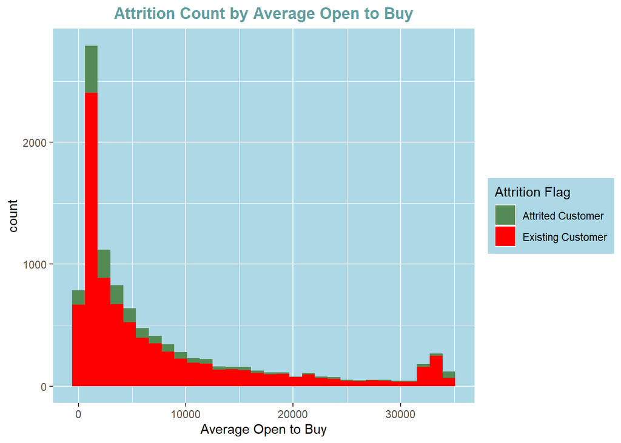

```r
ggplot(data = BankChurners,aes(x=Avg_Open_To_Buy,fill=Attrition_Flag))+geom_histogram(position = "stack",bins = 30)+labs(title = "Attrition Count by Average Open to Buy",x="Average Open to Buy",fill="Attrition Flag")+theme(panel.background = element_rect(fill = "lightblue"))+theme(plot.title = element_text(hjust = 0.5,face = "bold",colour = "cadetblue"))+scale_fill_manual(values=c("palegreen4","red"))+theme(legend.background = element_rect(fill = "lightblue"))
```

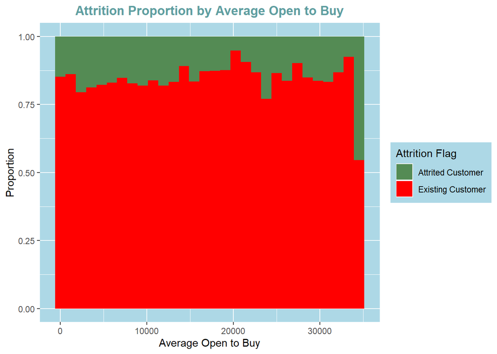

```r
ggplot(data = BankChurners,aes(x=Avg_Open_To_Buy,fill=Attrition_Flag))+geom_histogram(position = "fill",bins = 30)+labs(title = "Attrition Proportion by Average Open to Buy",x="Average Open to Buy",fill="Attrition Flag")+theme(panel.background = element_rect(fill = "lightblue"))+theme(plot.title = element_text(hjust = 0.5,face = "bold",colour = "cadetblue"))+scale_fill_manual(values=c("palegreen4","red"))+theme(legend.background = element_rect(fill = "lightblue"))+scale_y_continuous("Proportion")
```

```r
cor(BankChurners$Credit_Limit,BankChurners$Avg_Open_To_Buy) # Findinng correlation
```

```
## [1] 0.9959805
```

1. From the above graph we observe that the pattern of this graph seems so similar to the Credit Limit, the details of which we have mentioned above.
2. Also after finding the relationship between them we get that they have a very high correlation between them i.e. 0.9959. Therefore it is not required to keep both these variables. Anyone of them needs to be omitted.

### Attrition_Flag - Total_Amt_chng_Q4_Q1

```r
summary(BankChurners$Total_Amt_Chng_Q4_Q1)
```

```
##    Min. 1st Qu.  Median    Mean 3rd Qu.    Max.
##  0.0000  0.6310  0.7360  0.7599  0.8590  3.3970
```

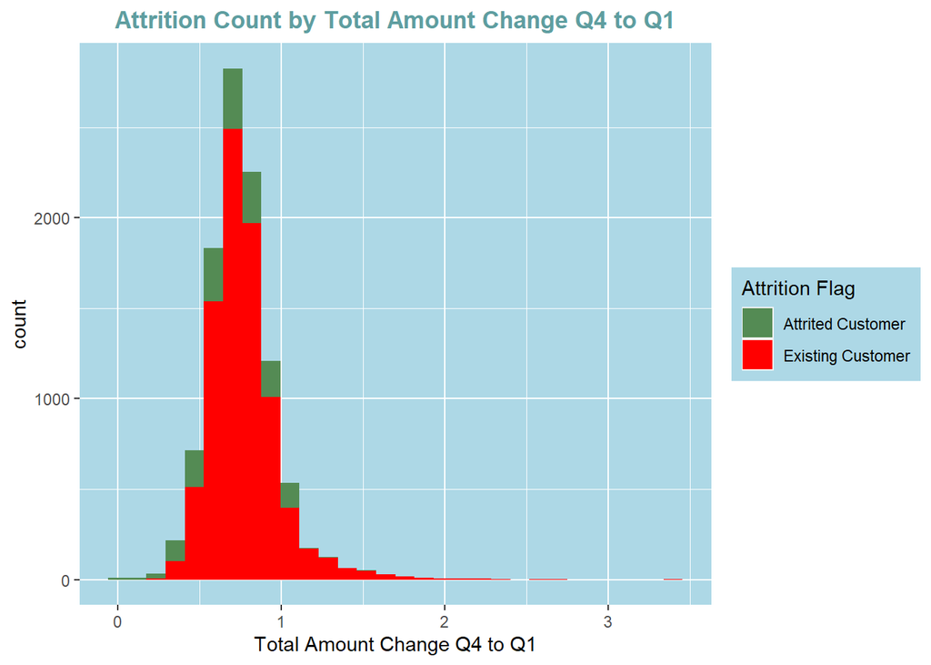

```r
ggplot(data = BankChurners,aes(x=Total_Amt_Chng_Q4_Q1,fill=Attrition_Flag))+geom_histogram(position = "stack",bins = 30)+labs(title = "Attrition Count by Total Amount Change Q4 to Q1",x="Total Amount Change Q4 to Q1",fill="Attrition Flag")+theme(panel.background = element_rect(fill = "lightblue"))+theme(plot.title = element_text(hjust = 0.5,face = "bold",colour = "cadetblue"))+scale_fill_manual(values=c("palegreen4","red"))+theme(legend.background = element_rect(fill = "lightblue"))
```

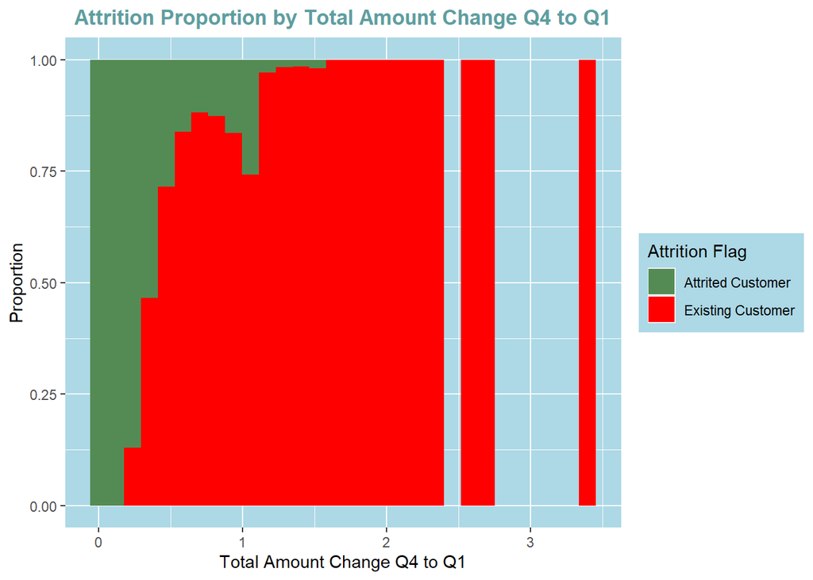

```r
ggplot(data = BankChurners,aes(x=Total_Amt_Chng_Q4_Q1,fill=Attrition_Flag))+geom_histogram(position = "fill",bins = 30)+scale_y_continuous("Proportion")+labs(title = "Attrition Proportion by Total Amount Change Q4 to Q1",x="Total Amount Change Q4 to Q1",fill="Attrition Flag")+theme(panel.background = element_rect(fill = "lightblue"))+theme(plot.title = element_text(hjust = 0.5,face = "bold",colour = "cadetblue"))+scale_fill_manual(values=c("palegreen4","red"))+theme(legend.background = element_rect(fill = "lightblue"))
```

1. From the above graph we get that there are maximum customers between 0.4-0.1 Total_Amt_Chng_Q4_Q1. This means that most of the customers got their amounts decreased from Q4 to Q1 which is infact a matter of concern for the bank.
2. From the second graph we observe that when Total_Amt_Chng_Q4_Q1 is 0, the bank has attrition rate of 100% which is indeed an alarming stage for the bank.
3. As the Total_Amt_Chng_Q4_Q1 incrases the attrition rate decreases.
4. When Total_Amt_Chng_Q4_Q1 is greater than 1.5, we see that there is 0 attrition rate which is a good sign.
5. The Bank should focus mainly on those customers who have Total_Amt_Chng_Q4_Q1 less than 1, because they are more prone to leaving the credit card service of the bank.
6. Indeed the Bank should try to know the reason behind their decreasing bank balance and frame the policies accordingly.

### Attrition_Flag - Total_Trans_Amt

```r
summary(BankChurners$Total_Trans_Amt)
```

```
##    Min. 1st Qu.  Median    Mean 3rd Qu.    Max.
##     510    2156    3899    4404    4741   18484
```

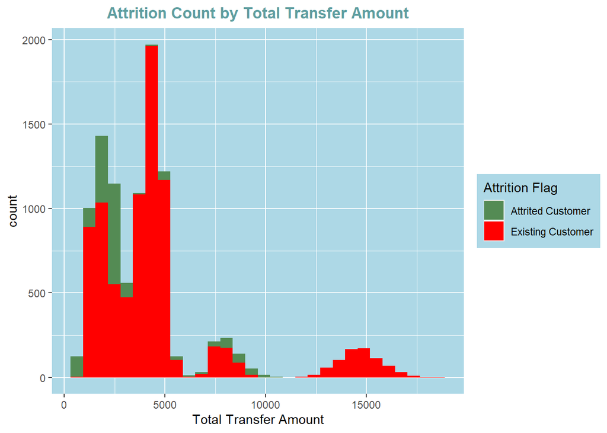

```r
ggplot(data = BankChurners,aes(x=Total_Trans_Amt,fill=Attrition_Flag))+geom_histogram(position = "stack",bins = 30)+labs(title = "Attrition Count by Total Transfer Amount",x="Total Transfer Amount",fill="Attrition Flag")+theme(panel.background = element_rect(fill = "lightblue"))+theme(plot.title = element_text(hjust = 0.5,face = "bold",colour = "cadetblue"))+scale_fill_manual(values=c("palegreen4","red"))+theme(legend.background = element_rect(fill = "lightblue"))
```

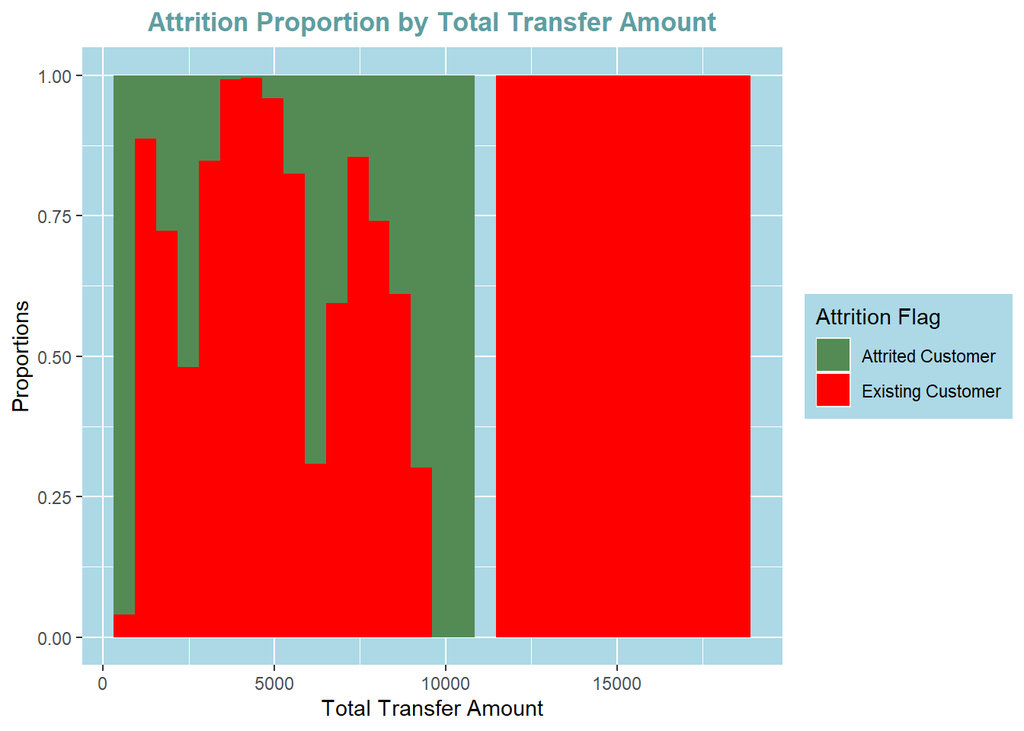

```r
ggplot(data = BankChurners,aes(x=Total_Trans_Amt,fill=Attrition_Flag))+geom_histogram(position = "fill",bins = 30)+labs(title = "Attrition Proportion by Total Transfer Amount",x="Total Transfer Amount",fill="Attrition Flag")+theme(panel.background = element_rect(fill = "lightblue"))+theme(plot.title = element_text(hjust = 0.5,face = "bold",colour = "cadetblue"))+scale_fill_manual(values=c("palegreen4","red"))+theme(legend.background = element_rect(fill = "lightblue"))+scale_y_continuous("Proportions")
```